# Predict food trend using social media data

Objective is to predict total sales volume using social media data.

```r
require(scales)
```

Read datasets for clementine sales and social media.

```r
social <- read.csv("/Users/kevalshah/Keval_Backup/University/UChicago/Capstone/Data/clementine_social.csv")

# Check summary statistics
#summary(social)
head(social[1:9])
```

```
##   Analysis_Date Blogs Forums Reviews Facebook Twitter Comments
## 1        1/3/10   795    285       6        0     774        0
## 2       1/10/10  1166    253       3        0     661        0
## 3       1/17/10   692    212       4        0     595        0
## 4       1/24/10   638    174       2        0     664        0
## 5       1/31/10   670    223       3        0     416        0
## 6        2/7/10   710    361       1        0     428        0
##   Google.trends.data Total_mentions
## 1                 86           1946
## 2                 65           2148
## 3                 73           1576
## 4                 65           1543
## 5                 46           1358
## 6                 49           1549
```

```r
sales <- read.csv("/Users/kevalshah/Keval_Backup/University/UChicago/Capstone/Data/clementine_sales.csv")

# Check summary statistics
#summary(sales)
head(sales)
```

```
##    Period Scan.Date       Geography    Product  Dollars  Volume
## 1  1/9/10    1/9/10 Total U.S. PROJ Clementine 27659560 5541236
## 2 1/16/10   1/16/10 Total U.S. PROJ Clementine 25247902 5035414
## 3 1/23/10   1/23/10 Total U.S. PROJ Clementine 25617283 5052122
## 4 1/30/10   1/30/10 Total U.S. PROJ Clementine 17500257 3249063
## 5  2/6/10    2/6/10 Total U.S. PROJ Clementine 20281201 3909343
## 6 2/13/10   2/13/10 Total U.S. PROJ Clementine 18320152 3416482
```

Let’s make some time series plots for social media mentions and sales data for Clementines.

```r
# Social media mentions plot

# Date formatting
analysis_date = as.Date(social[,1], "%m/%d/%y")
str(analysis_date)
```

```
##  Date[1:287], format: "2010-01-03" "2010-01-10" "2010-01-17" "2010-01-24" ...
```

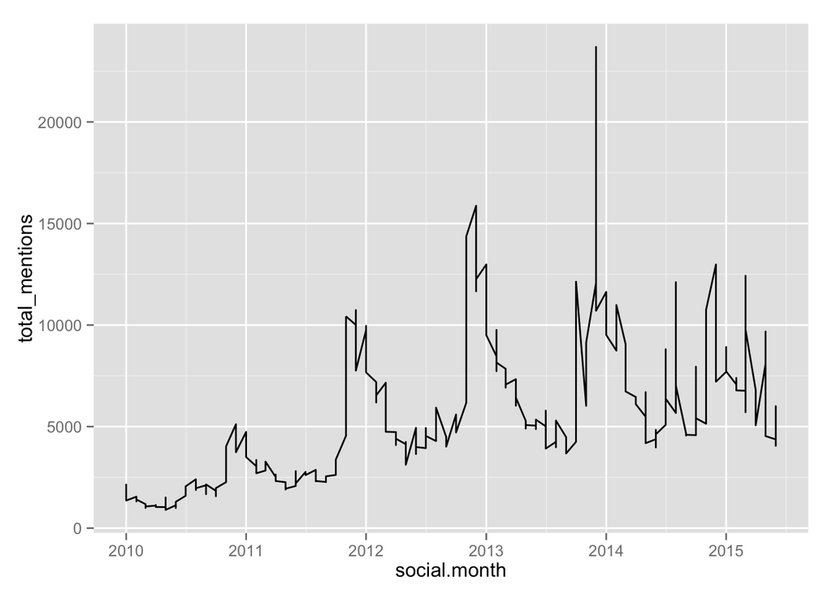

```r
# Create a variable for month to aggregate / sum all observations for a particular month
social$month = as.Date(cut(analysis_date, breaks = "month"))
#social

total_mentions = social[,9]

# Create a dataset containing analysis date, month of analysis date and total social media mentions for plotting a observations aggregated at a monthly level.
social1 <- data.frame(analysis_date, social$month, total_mentions)
#social1

require(ggplot2)
# Time series plot by monthly total observations
p <- ggplot(social1, aes(x=social.month, y=total_mentions))
p + geom_line()
```

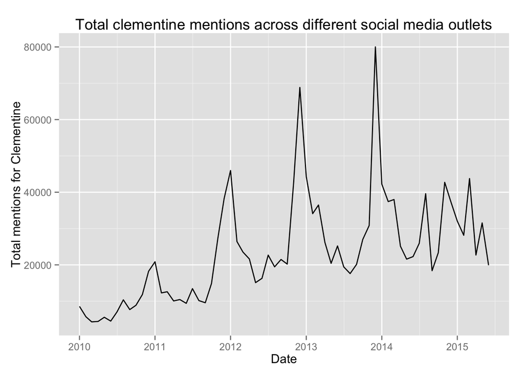

```r
# add up all observations(total_mentions) for the month
p = p + stat_summary(fun.y = sum, geom = "line")
p = p + ggtitle ("Total clementine mentions across different social media outlets")
p + xlab("Date") +  ylab ("Total mentions for Clementine")
```

```r
#p + scale_x_date(labels = date_format("%y/%m"), breaks = "1 month")

# Plotting time series with curve / trendline
#ggplot(socialts,aes(x=social.month, y=total_mentions)) +
#  geom_point(aes(colour = total_mentions)) +
#  scale_colour_gradient2(low = "blue", mid = "green" , high = "red", midpoint = 4738 ) +
#  geom_smooth(color = "red",size = 1) +
#  scale_y_continuous(limits = c(899,23695)) +
#  ggtitle ("Total clementine mentions across different social media outlets") +
#  xlab("Date") +  ylab ("Total mentions for Clementine")
```

```r
# Sales data plot

# Date formatting
period = as.Date(sales[,1], "%m/%d/%y")
str(period)
```

```
##  Date[1:260], format: "2010-01-09" "2010-01-16" "2010-01-23" "2010-01-30" ...
```

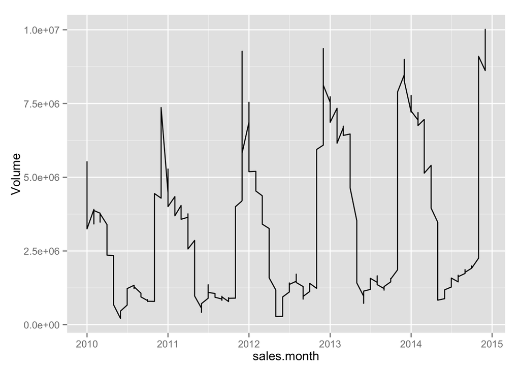

```r
Volume = sales[,6]

# Create a variable for month to aggregate / sum all observations for a particular month
sales$month = as.Date(cut(period, breaks = "month"))
#sales

# Bind period, sales month and volume into a data frame
sales1 <- data.frame(period, sales$month, Volume)

# Now, let's plot time series of montly aggregated total Clementine sales volume
p <- ggplot(sales1, aes(x=sales.month, y=Volume))
p + geom_line()
```

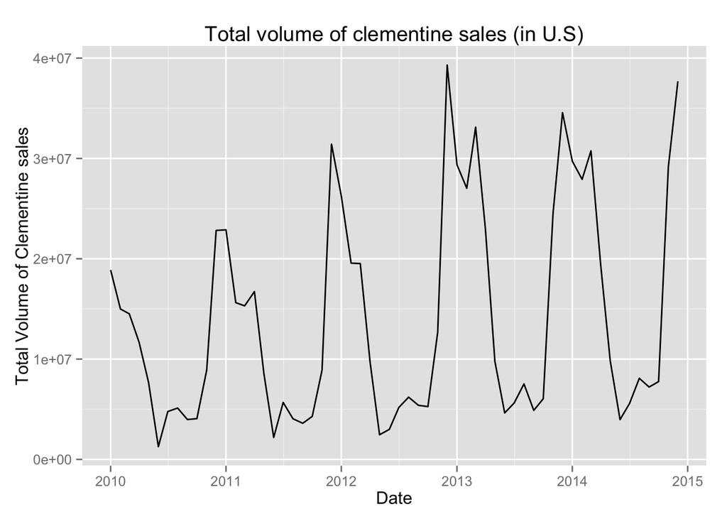

```r
# add up all observations(total_mentions) for the month
p = p + stat_summary(fun.y = sum, geom = "line")
#p = p + scale_y_continuous(limits = c(211151,10017414))
p = p + ggtitle ("Total volume of clementine sales (in U.S)")
p + xlab("Date") +  ylab ("Total Volume of Clementine sales")
```

Next steps:

- Review time series textbook / literature for the right technique to deal with a seasonality: detrending, differencing (average out)
- Understanding time series seasonal fluctuations or random fluctuations.
- Decomposing the time series. There appears to be some seasonality in sales data. Look into smoothing, differencing and other time series techniques to control for seasonality.
- Stationarity check.

http://a-little-book-of-r-for-time-series.readthedocs.org/en/latest/src/timeseries.html

Based on text readings:

1. Decompose the time series and obtain trend, seasonal and random noise component from series.
2. Remove seasonal component. The remaining time series should be trend and random noise.
3. Regression modeling: Use dummy variables for each of months, maybe season as predictors and run the model. Note R-Squared.

Decomposing the time series into trend, seasonal and irregular components.

```r
# Columns required time and volume

#Using zoo object
require(zoo)
```

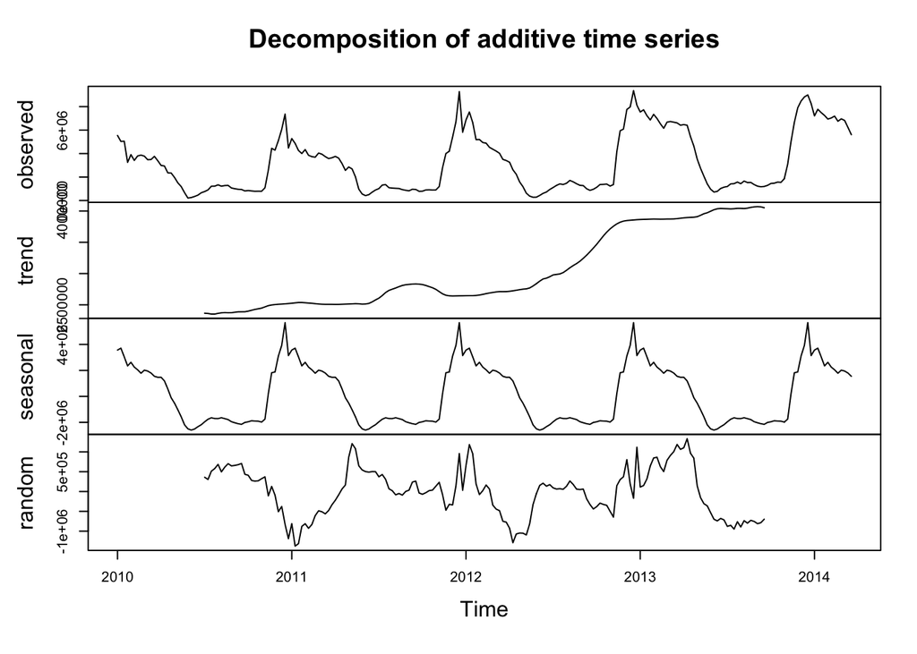

```r
salests = sales[, c(1,6)]
salestsz = read.zoo(salests, format = "%m/%d/%y", index.column = 1)
View(salestsz)

#Decompose zoo object
salestszDec <- ts(salestsz, frequency=52, start=c(2010, 1), end=c(2014,12))
salestsDec1 <- decompose(salestszDec, type=c("additive"))
plot(salestsDec1)
```

```r
# Frequency = 52 weeks in year. i.e 52 # of observations in one year.
#salestsDec <- ts(salests[,2], frequency=52, start=c(2010, 1), end=c(2014,12))
#salestsDec <- decompose(salestsDec, type=c("additive"))
#plot(salestsDec)
```

Plot seasonally adjusted time series

```r
# Check object type
class(salestsDec1$seasonal)
```

```
## [1] "ts"
```

```r
class(salestszDec)
```

```
## [1] "ts"
```

```r
# Both are 'ts' object, so we need to convert to numeric to be able to perform math operation of subtracting seasonal component from the original series.


salestszDec <- as.numeric(unlist(salestszDec))
class(salestszDec)
```

```
## [1] "numeric"
```

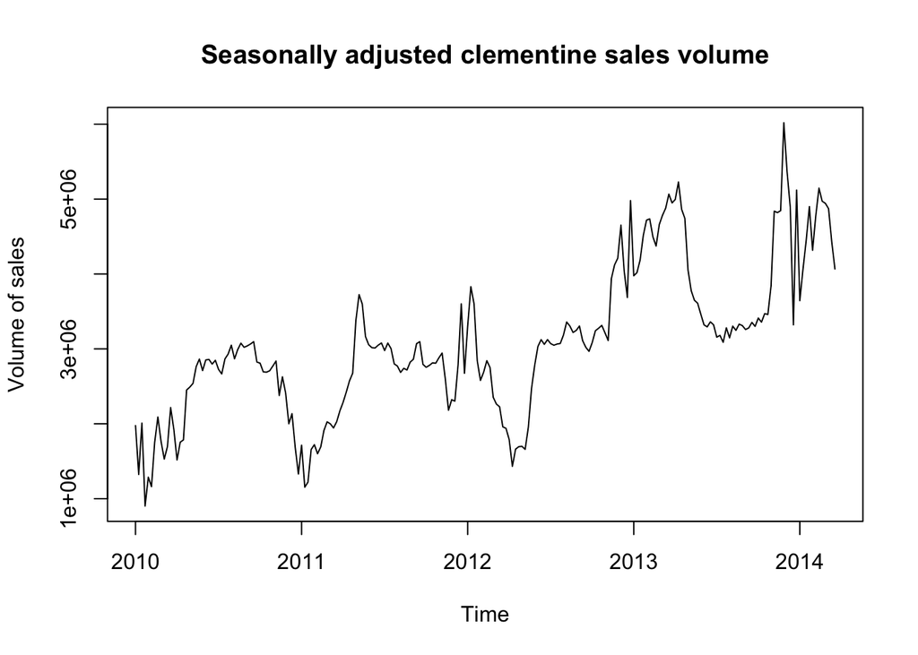

```r
salestszSeasonallyAdjusted <- salestszDec - salestsDec1$seasonal

#Plot seasonally adjusted time series
plot(salestszSeasonallyAdjusted, xlab="Time", ylab="Volume of sales", main="Seasonally adjusted clementine sales volume")
```